# Tanzanian Water Pumps

After running the model, it is very important to assess the model before using it to predict on test set. First of all, we would like to verify feature importance:

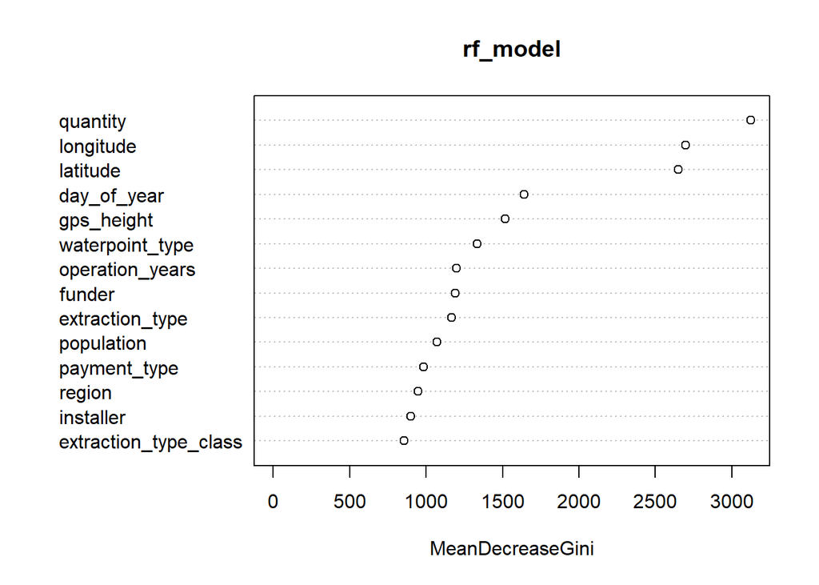

```r
# Calculate feature importance
model_importance <- importance(rf_model)

# Plot feature importance
varImpPlot(rf_model)
```

```r
# We can see here that some variables are more important than others in predicting status_group
```

Let’s identify variables which are not good predictors to our model (done in the first model run):

```r
# Create a column from rowname
#model_importance <- rownames_to_column(as.data.frame(model_importance), var = "var")

# Calculate average feature importance and standard deviation
#mean(model_importance$MeanDecreaseGini)
#sd(model_importance$MeanDecreaseGini)
#median(model_importance$MeanDecreaseGini)

# Let's drop from model variables with less feature importance. We will identify as not useful all those variables with meandecreasegini less that average-2sd

# Let's calculate a threshold
#model_importance$threshold <- mean(model_importance$MeanDecreaseGini) -0.5*sd(model_importance$MeanDecreaseGini)

# Display variables not adding value
#model_importance %>%
  #filter(MeanDecreaseGini<threshold) %>%
  #arrange(MeanDecreaseGini)
```

```r
# Predict on test set
validation_set_rf$rf_predictions <- predict(rf_model, validation_set_rf)
```

Verify performance on validation set:

```r
validation_set_rf <- droplevels(validation_set_rf)

# Compute overall model accuracy accuracy
confusionMatrix(validation_set_rf$rf_predictions, validation_set_rf$status_group)
```

```
## Confusion Matrix and Statistics
##
##                          Reference
## Prediction                functional functional needs repair non functional
##   functional                    6856                      75            127
##   functional needs repair         10                     807             19
##   non functional                  30                      25           4543
##
## Overall Statistics
##
##                Accuracy : 0.9771
##                  95% CI : (0.9743, 0.9797)
##     No Information Rate : 0.552
##     P-Value [Acc > NIR] : < 2.2e-16
##
##                   Kappa : 0.958
##
##  Mcnemar's Test P-Value : < 2.2e-16
##
## Statistics by Class:
##
##                      Class: functional Class: functional needs repair
## Sensitivity                     0.9942                        0.88975
## Specificity                     0.9639                        0.99750
## Pos Pred Value                  0.9714                        0.96531
## Neg Pred Value                  0.9926                        0.99142
## Prevalence                      0.5520                        0.07261
## Detection Rate                  0.5488                        0.06460
## Detection Prevalence            0.5650                        0.06692
## Balanced Accuracy               0.9791                        0.94362
##                      Class: non functional
## Sensitivity                         0.9689
## Specificity                         0.9930
## Pos Pred Value                      0.9880
## Neg Pred Value                      0.9815
## Prevalence                          0.3754
## Detection Rate                      0.3637
## Detection Prevalence                0.3681
## Balanced Accuracy                   0.9809
```

Nevertheless, looking at sensitivity and specificity we can see that model is performing in a very different way across three categories. Model is fairly good in detecting functional and not functional water pumps, but it finds more difficult to find water pumps that need some repairs.

The issue here is that we do have very few observations for category “functional needs repair” with respect to other categories. That’s why I would apply undersampling/oversampling techniques in order to rebalance target variable.

However,for the sake of this exercise, we reach a satisfactory performance and applying/optimizing SMOTE techniques would require time.

Just a last note. Having more time to work on this ,I would have followed my standard methodological approach:

1. Implement several algorithms with standard hyper-parameters, computing accuracy rate and confusion matrix for each one
2. Choose the one with best performance at baseline
3. Implement a grid-search in order to fine-tune standard hyper-parameters of the best model

Predict status on test set:

```r
# Predict on test set
test_set_rf$rf_predictions <- predict(rf_model, test_set_rf)
```

Prepare and write file for submission:

```r
# Prepare file
Submission <- test_set_rf %>%
  select(id, rf_predictions)

names(Submission)[names(Submission) == "rf_predictions"] <- "status_group"

# Write CSV
write.csv(Submission,"submission_GDB_2021.csv", row.names = FALSE)
```